# Machine Learning Course: Prediction Assignment

Cuong Pham V

2024-01-12

## Background

Using devices such as Jawbone Up, Nike FuelBand, and Fitbit it is now possible to collect a large amount of data about personal activity relatively inexpensively. These type of devices are part of the quantified self movement – a group of enthusiasts who take measurements about themselves regularly to improve their health, to find patterns in their behavior, or because they are tech geeks. One thing that people regularly do is quantify how much of a particular activity they do, but they rarely quantify how well they do it. In this project, your goal will be to use data from accelerometers on the belt, forearm, arm, and dumbell of 6 participants. They were asked to perform barbell lifts correctly and incorrectly in 5 different ways. More information is available from the website here: http://web.archive.org/web/20161224072740/http:/groupware.les.inf.puc-rio.br/har (see the section on the Weight Lifting Exercise Dataset).

Data

The training data for this project are available here:

https://d396qusza40orc.cloudfront.net/predmachlearn/pml-training.csv

The test data are available here:

https://d396qusza40orc.cloudfront.net/predmachlearn/pml-testing.csv

The data for this project come from this source: http://web.archive.org/web/20161224072740/http:/groupware.les.inf.puc-rio.br/har

## Load the necessary libraries

```r
library(lattice)
library(ggplot2)
library(caret)
library(kernlab)
library(rattle)
library(corrplot)
set.seed(1234)
```

## Data preparation

```r
traincsv <- read.csv(url("https://d396qusza40orc.cloudfront.net/predmachlearn/pml-training.csv"))
testcsv <- read.csv(url("https://d396qusza40orc.cloudfront.net/predmachlearn/pml-testing.csv"))

# cleaning the data by removing na columns, metadata which is not relevant to the outcome.
# also remove zero variance variables.
traincsv <- traincsv[,colMeans(is.na(traincsv)) < .9]
traincsv <- traincsv[,-c(1:7)]
nvz <- nearZeroVar(traincsv)
traincsv <- traincsv[,-nvz]
dim(traincsv)
```

```
## [1] 19622    53
```

```r
# create validation and training set from training dataset
inTrain <- createDataPartition(y=traincsv$classe, p=0.7, list=F)
train <- traincsv[inTrain,]
valid <- traincsv[-inTrain,]
control <- trainControl(method="cv", number=3, verboseIter=F)
```

## Prediction

Four prediction methods will be used including

1. Random Forests
2. Decision Tree
3. Gradient Boosting Machine (GBM)
4. Support Vector Machine (SVM)

### Randome forests

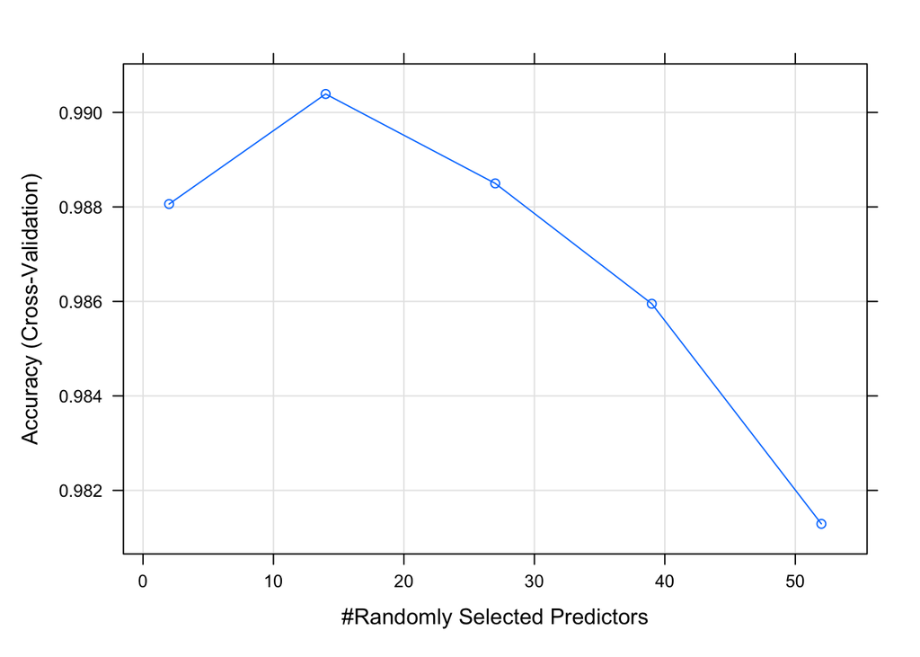

```r
mod_rf <- train(classe~., data=train, method="rf", trControl = control, tuneLength = 5)
pred_rf <- predict(mod_rf, valid)
cmrf <- confusionMatrix(pred_rf, factor(valid$classe))
plot(mod_rf) # plot random forest graph
```

The Random Forest model achieved high accuracy and Kappa scores, with the best performance observed when **mtry=14**, the **accuracy = 0.9904** and **Kappa = 0.9878**

### Decision trees

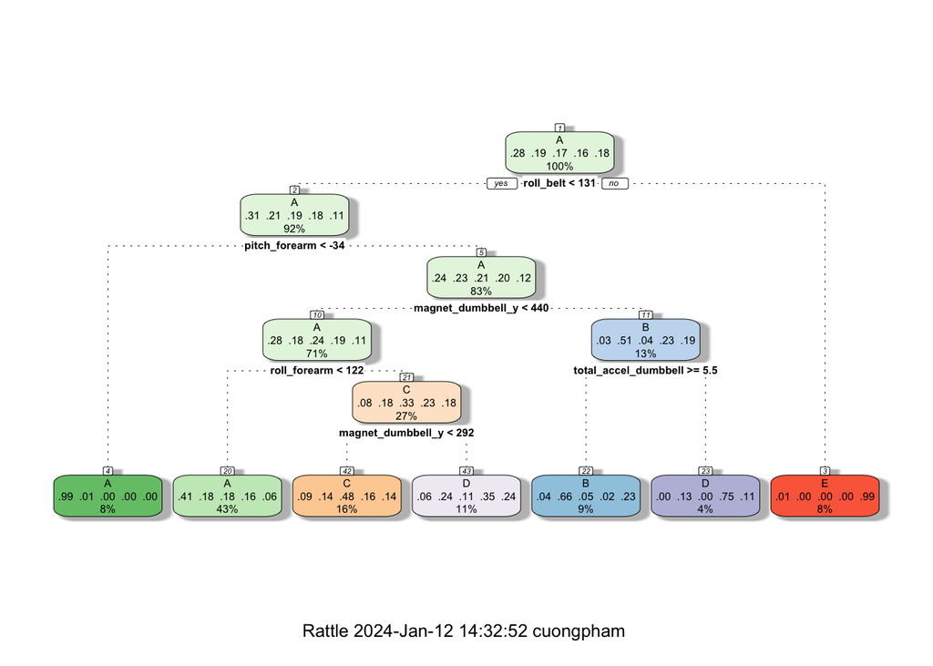

```r
mod_trees <- train(classe~., data=train, method="rpart", trControl = control, tuneLength = 5)
pred_trees <- predict(mod_trees, valid)
cmtrees <- confusionMatrix(pred_trees, factor(valid$classe))
fancyRpartPlot(mod_trees$finalModel)
```

The model achieved varying levels of accuracy and Kappa scores for different values of the complexity parameter (cp). The optimal model had a **cp=0.02085241**.

### Gradient Boosting Machine (GBM)

```r
mod_gbm <- train(classe~., data=train, method="gbm", trControl = control, tuneLength = 5, verbose = F)
pred_gbm <- predict(mod_gbm, valid)
cmgbm <- confusionMatrix(pred_gbm, factor(valid$classe))
```

The model achieved high accuracy and Kappa scores, with the best performance observed when **interaction.depth** was set to **5**, **n.trees** was set to **250**, and other tuning parameters were held constant at specified values.

### Support Vector Machine (SVM)

```r
mod_svm <- train(classe~., data=train, method="svmLinear", trControl = control, tuneLength = 5, verbose = F)
pred_svm <- predict(mod_svm, valid)
cmsvm <- confusionMatrix(pred_svm, factor(valid$classe))
```

The model achieved an accuracy of approximately **78.34%** and a Kappa coefficient of approximately **72.46%**.

### Compare models

```r
models <- c("Tree", "RF", "GBM", "SVM")
accuracy <- round(c( cmtrees$overall[1], cmrf$overall[1], cmgbm$overall[1], cmsvm$overall[1]),3)
oos_error <- 1 - accuracy
data.frame(accuracy = accuracy, oos_error = oos_error, row.names = models)
```

```
##      accuracy oos_error
## Tree    0.537     0.463
## RF      0.995     0.005
## GBM     0.992     0.008
## SVM     0.781     0.219
```

#### Prediction

The Random Forest and Gradient Boosting Machine models show very high accuracy and low out-of-sample error, indicating strong performance. I used the Random Forest for the prediction

```r
pred <- predict(mod_rf, testcsv)
print(pred)
```

```
##  [1] B A B A A E D B A A B C B A E E A B B B
## Levels: A B C D E
```